# BathSoap

```r
library(readr)
BathSoap <- read_csv("C:/Trading detail/STUDY/01_MSBA/02 MSBA ML/Final/BathSoap.csv")
library(caret)
library(factoextra)
library(hrbrthemes)
library(GGally)
library(viridis)
set.seed(200)
```

**Comments** finding which brand is customer loyal with column defined in data : here loyalty is defined by purchase behavior of the customer in “other999” or rest of 8 brands, combining Br.Cd.57,144,Br.Cd.55,Br.Cd.272,Br.Cd.286,Br.Cd.24,Br.Cd.481,Br.Cd.352,Br.Cd.5 as one brand and finding max loyalty to a specific brand against “other999”

**comment** if we consider K=2 cluster will be classified either high or low with this will not show true information about the data available here we consider K=3 as we feel 3 cluster are able to classify characteristic in a efficient way and can be represent easily

```r
BathSoap$maxLoyality<-as.numeric(apply(BathSoap[,23:31],1,max))
```

1. 1. The variables that describe purchase behavior (including brand loyalty) **Comments** variable considered here are No. of Brands,Brand Runs,Total Volume,No. of Trans,Value,Trans / Brand Runs,Vol/Tran,Avg. Price,Others 999and maxLoyality.

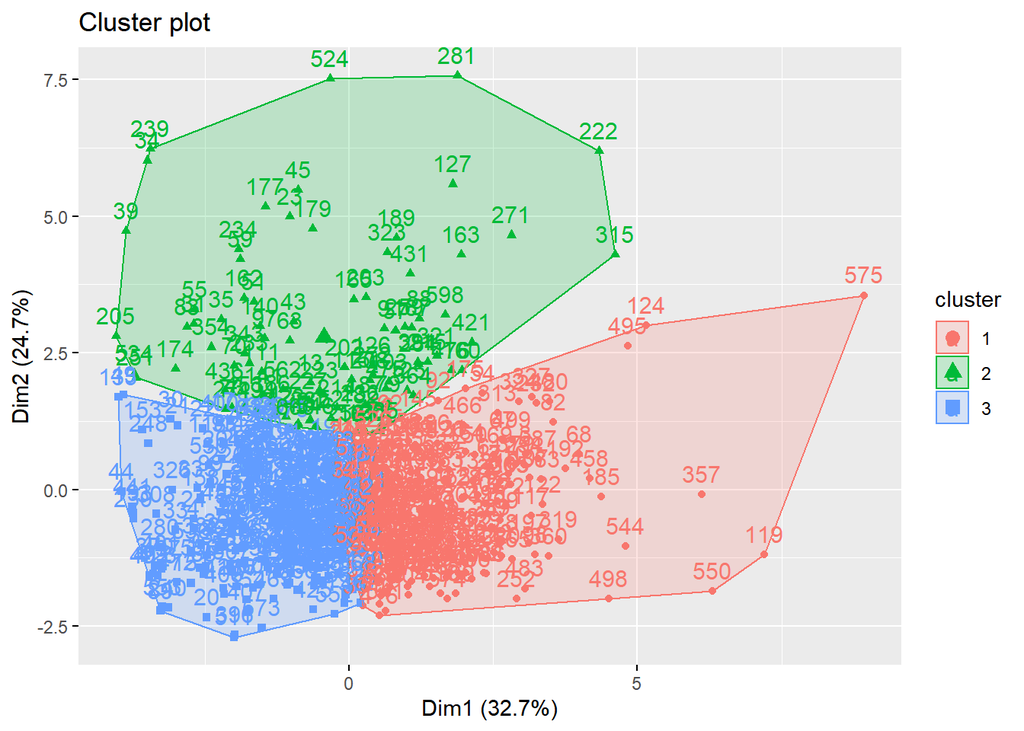

```r
subset10<-BathSoap[,c(12:19,31,47)]
subset10.s<-as.data.frame(scale(subset10))

model10 <- kmeans(subset10.s,3,nstart = 50)

fviz_cluster(model10,subset10.s)
```

```r
result10<-as.data.frame(cbind(1:nrow(model10$centers),model10$centers))
result10$V1<-as.factor(result10$V1)
result10
```

|  | V1 | No. of Brands | Brand Runs | Total Volume | No. of Trans | Value | Trans / Brand Runs | Vol/Tran | Avg. Price | Others 999 | maxLoyality |
| --- | --- | --- | --- | --- | --- | --- | --- | --- | --- | --- | --- |
| 1 | 1 | 0.8245850 | 0.8140166 | 0.1909014 | 0.7311192 | 0.3314374 | -0.26278191 | -0.3734480 | 0.1653464 | 0.07370228 | -0.5543009 |
| 2 | 2 | -0.5437006 | -0.5981191 | 1.3433296 | -0.1465138 | 0.8168767 | 1.00873663 | 1.6388835 | -0.7655578 | -0.45799120 | 0.5845350 |
| 3 | 3 | -0.5883629 | -0.5598152 | -0.6389822 | -0.6365027 | -0.5908135 | -0.09839987 | -0.2101059 | 0.1066907 | 0.08750853 | 0.3205481 |

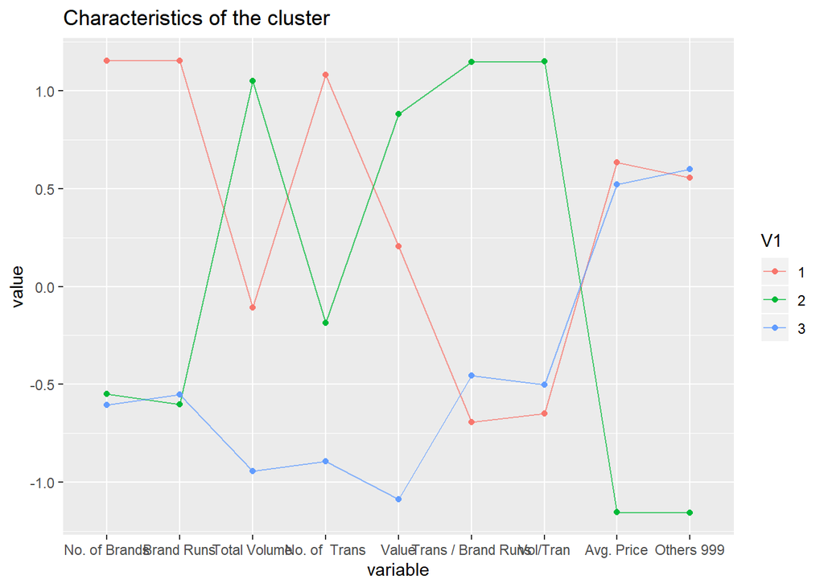

```r
ggparcoord(result10,columns = 2:10, groupColumn = 1,showPoints = TRUE, title = "Characteristics of the cluster",alphaLines = 0.7 )
```

1. 2. The variables that describe the basis for purchase

**Comments** : variable considered here are Pur Vol No Promo - %,Pur Vol Promo 6 %,Pur Vol Other Promo %,Pr Cat 1,Pr Cat 2,Pr Cat 3,Pr Cat 4,PropCat 5,PropCat 6,PropCat 7,PropCat 8,PropCat 9,PropCat 10,PropCat 11,PropCat 12,PropCat 13,PropCat 14,PropCat 15

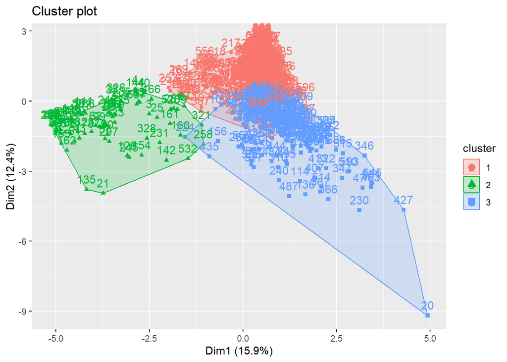

```r
subset20<-BathSoap[,c(20:22,32:46)]
subset20.s<-as.data.frame(scale(subset20))

model20 <- kmeans(subset20.s,3,nstart = 50)

fviz_cluster(model20,subset20.s)
```

```r
result20<-as.data.frame(cbind(1:nrow(model20$centers),model20$centers))
result20$V1<-as.factor(result20$V1)
result20
```

|  | V1 | Pur Vol No Promo - % | Pur Vol Promo 6 % | Pur Vol Other Promo % | Pr Cat 1 | Pr Cat 2 | Pr Cat 3 | Pr Cat 4 | PropCat 5 | PropCat 6 | PropCat 7 | PropCat 8 | PropCat 9 | PropCat 10 | PropCat 11 | PropCat 12 | PropCat 13 | PropCat 14 | PropCat 15 |
| --- | --- | --- | --- | --- | --- | --- | --- | --- | --- | --- | --- | --- | --- | --- | --- | --- | --- | --- | --- |
| 1 | 1 | 0.2860651 | -0.2360563 | -0.1703973 | -0.4651435 | 0.5449425 | -0.2889248 | 0.1995556 | 0.4650497 | -0.02823256 | -0.03967626 | -0.1912417 | -0.03863186 | -0.1612525 | 0.06575023 | -0.09960688 | -0.2035148 | -0.2913920 | 0.02639850 |
| 2 | 2 | 0.1856666 | -0.3842112 | 0.1912587 | -0.7825205 | -1.1334328 | 2.3701003 | -0.3204763 | -1.0914607 | -0.17089192 | -0.44919415 | -0.4629703 | -0.16226455 | -0.2570818 | -0.22953559 | -0.16301187 | -0.2325107 | 2.3724613 | -0.22967026 |
| 3 | 3 | -0.5626809 | 0.5576736 | 0.2131738 | 1.1091649 | -0.4708722 | -0.4653448 | -0.2106562 | -0.3516447 | 0.11719213 | 0.24917427 | 0.5131099 | 0.13143273 | 0.3787795 | -0.01931633 | 0.23567662 | 0.4408922 | -0.4620933 | 0.04781956 |

1. 3. The variables that describe both purchase behavior and basis of purchase

**Comments** considering both variable which are considered in above 2 models

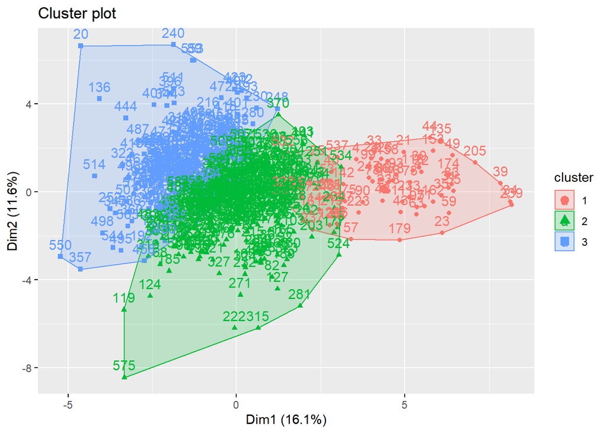

```r
subset30<-BathSoap[,c(20:22,32:46,12:19,31,47)]
subset30.s<-as.data.frame(scale(subset30))

model30 <- kmeans(subset30.s,3,nstart = 50)

fviz_cluster(model30,subset30.s)
```

```r
result30<-as.data.frame(cbind(1:nrow(model30$centers),model30$centers))
result30$V1<-as.factor(result30$V1)
result30
```

|  | V1 | Pur Vol No Promo - % | Pur Vol Promo 6 % | Pur Vol Other Promo % | Pr Cat 1 | Pr Cat 2 | Pr Cat 3 | Pr Cat 4 | PropCat 5 | PropCat 6 | PropCat 7 | PropCat 8 | PropCat 9 | PropCat 10 | PropCat 11 | PropCat 12 | PropCat 13 | PropCat 14 | PropCat 15 | No. of Brands | Brand Runs | Total Volume | No. of Trans | Value | Trans / Brand Runs | Vol/Tran | Avg. Price | Others 999 | maxLoyality |
| --- | --- | --- | --- | --- | --- | --- | --- | --- | --- | --- | --- | --- | --- | --- | --- | --- | --- | --- | --- | --- | --- | --- | --- | --- | --- | --- | --- | --- | --- |
| 1 | 1 | 0.2413117 | -0.4871882 | 0.2304547 | -0.7960149 | -1.2358341 | 2.5300303 | -0.3579166 | -1.1538285 | -0.24964584 | -0.45522491 | -0.4787781 | -0.121030458 | -0.2558533 | -0.2835593 | -0.1746531 | -0.2404776 | 2.5320827 | -0.25277167 | -0.59852165 | -0.8120867 | 0.09190381 | -0.42903264 | -0.55575082 | 1.07696718 | 0.5271963 | -1.3330597 | -1.28083436 | 0.4731207 |
| 2 | 2 | 0.2090974 | -0.1364506 | -0.1700992 | -0.4706100 | 0.4989475 | -0.2389930 | 0.2123491 | 0.4275207 | -0.06422936 | -0.04178485 | -0.2009161 | 0.025290644 | -0.1761227 | 0.1279772 | -0.1320548 | -0.2035615 | -0.2424143 | 0.01179982 | 0.13504595 | 0.0516106 | 0.24983473 | 0.09718829 | 0.16004751 | -0.08066505 | 0.1821607 | -0.2930420 | -0.02781521 | -0.2105584 |
| 3 | 3 | -0.4557413 | 0.4141771 | 0.2195979 | 1.1152939 | -0.4458616 | -0.4728357 | -0.2492727 | -0.3484203 | 0.20215572 | 0.23521949 | 0.5253562 | -0.001920562 | 0.4024987 | -0.1261990 | 0.2957033 | 0.4456427 | -0.4675039 | 0.06862778 | -0.02716745 | 0.1962202 | -0.47496493 | -0.02015521 | -0.08658905 | -0.23858152 | -0.5092916 | 0.9910538 | 0.50288493 | 0.2053002 |

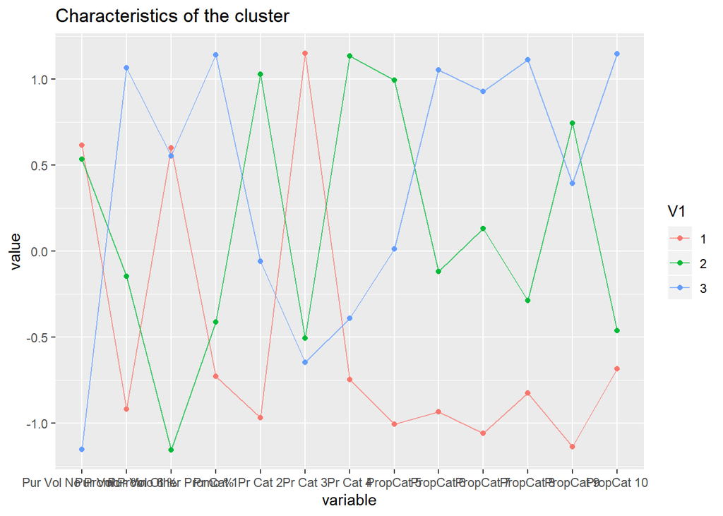

```r
ggparcoord(result30,columns = 2:14, groupColumn = 1,showPoints = TRUE, title = "Characteristics of the cluster",alphaLines = 0.7 )
```

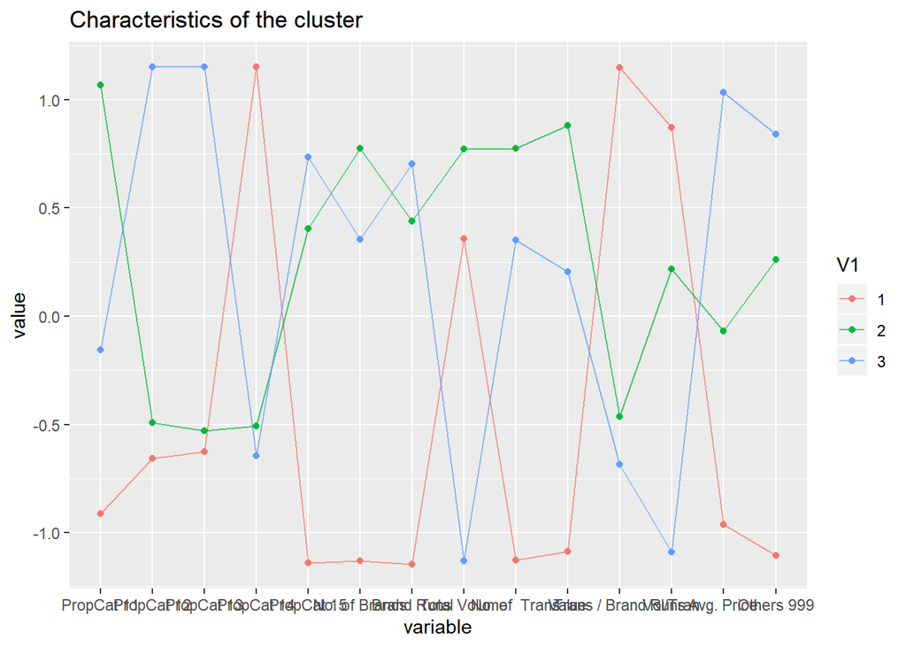

```r
ggparcoord(result30,columns = 15:28, groupColumn = 1,showPoints = TRUE, title = "Characteristics of the cluster",alphaLines = 0.7 )
```

**comments**: cluster 1(68) ) are loyal to one brand and fall price category 3 with proposition category 14. cluster 2(340) is not keen on any promotion not responsive to any suggestion given to them. enjoy promotion for purchase of goods and utilize suggestions also offered to them. cluster 3(192) enjoy promotion for purchase of good and utilize suggestion also offered to them

2. Select what you think is the best segmentation and comment on the characteristics (demographic,brand loyalty, and basis for purchase) of these clusters. (This information would be used to guide thedevelopment of advertising and promotional campaigns.)

**Comments** considering these demographic SEC,FEH,MT,SEX,AGE,EDU,HS,CHILD,CS,Affluence Index and all other variables considers above

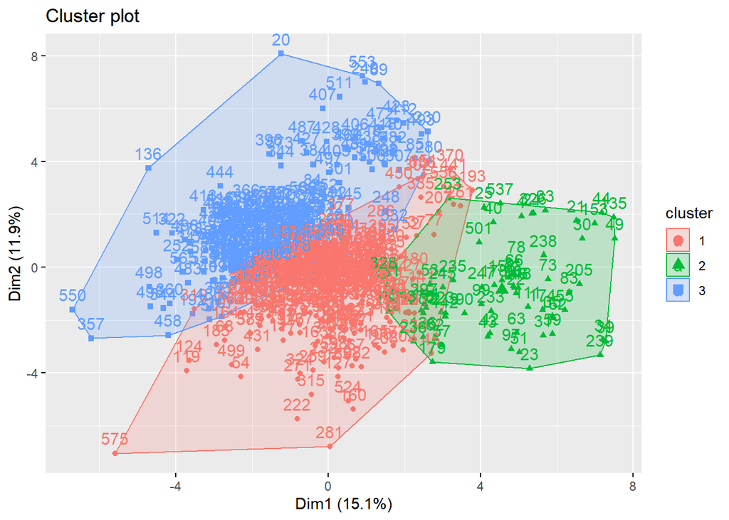

```r
subset40<-BathSoap[,c(2,6,7,8,9,10,11,12:19,31,47,20:22,32:46)]
subset40.s<-as.data.frame(scale(subset40))

model40 <- kmeans(subset40.s,3,nstart = 50)

fviz_cluster(model40,subset40.s)
```

```r
result40<-as.data.frame(cbind(1:nrow(model40$centers),model40$centers))
result40$V1<-as.factor(result40$V1)
model40$size
```

```
## [1] 315  67 218
```

```r
result40
```

|  | V1 | SEC | AGE | EDU | HS | CHILD | CS | Affluence Index | No. of Brands | Brand Runs | Total Volume | No. of Trans | Value | Trans / Brand Runs | Vol/Tran | Avg. Price | Others 999 | maxLoyality | Pur Vol No Promo - % | Pur Vol Promo 6 % | Pur Vol Other Promo % | Pr Cat 1 | Pr Cat 2 | Pr Cat 3 | Pr Cat 4 | PropCat 5 | PropCat 6 | PropCat 7 | PropCat 8 | … |
| --- | --- | --- | --- | --- | --- | --- | --- | --- | --- | --- | --- | --- | --- | --- | --- | --- | --- | --- | --- | --- | --- | --- | --- | --- | --- | --- | --- | --- | --- | --- |
| 1 | 1 | 0.2539190 | 0.02494233 | 0.00485612 | 0.2907063 | -0.2125774 | 0.1284240 | -0.06574527 | 0.10942339 | 0.0125882 | 0.30915731 | 0.086290654 | 0.1978029 | -0.05921173 | 0.2498848 | -0.3324339 | -0.02008366 | -0.17142569 | 0.2500122 | -0.1759431 | -0.1882130 | -0.5058734 | 0.4885328 | -0.2179171 | 0.2514828 | 0.4358650 | -0.06666136 | -0.03095463 | -0.2309290 | … |
| 2 | 2 | 0.8203196 | -0.19475380 | -0.85124466 | -0.1611985 | 0.3233333 | -0.1594893 | -0.83369596 | -0.62033582 | -0.8274351 | 0.08216322 | -0.436161232 | -0.5635574 | 1.09646674 | 0.5314332 | -1.3428879 | -1.28076057 | 0.49402504 | 0.2977059 | -0.5099199 | 0.1661563 | -0.8106072 | -1.2138944 | 2.5371221 | -0.3820453 | -1.1862756 | -0.20377760 | -0.45463049 | -0.4780725 | … |
| 3 | 3 | -0.6190179 | 0.02381501 | 0.25460419 | -0.3705147 | 0.2077915 | -0.1365494 | 0.35122655 | 0.03254189 | 0.2361141 | -0.47197013 | 0.009363517 | -0.1126127 | -0.25142925 | -0.5244024 | 0.8930742 | 0.42264821 | 0.09586887 | -0.4527530 | 0.4109482 | 0.2208927 | 0.9800954 | -0.3328299 | -0.4648775 | -0.2459635 | -0.2652156 | 0.15895150 | 0.18445390 | 0.4806123 | … |

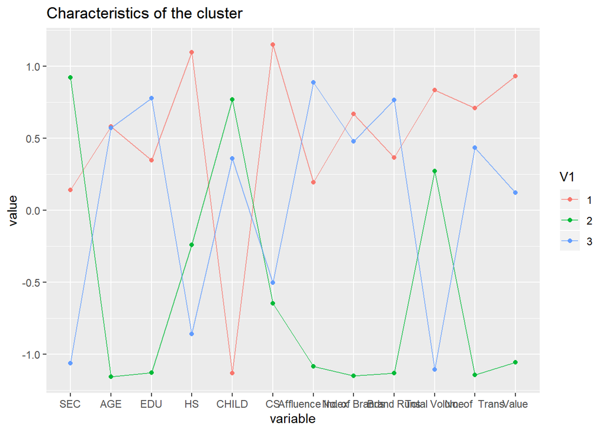

```r
subset40$clusters<-model40$cluster
# Formation of clusters
ggparcoord(result40,columns = 2:13, groupColumn = 1,showPoints = TRUE, title = "Characteristics of the cluster",alphaLines = 0.7 )
```

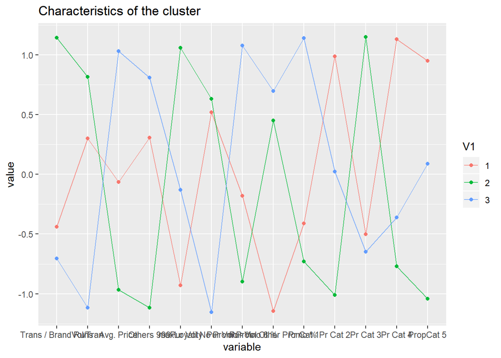

```r
ggparcoord(result40,columns = 14:26, groupColumn = 1,showPoints = TRUE, title = "Characteristics of the cluster",alphaLines = 0.7 )
```

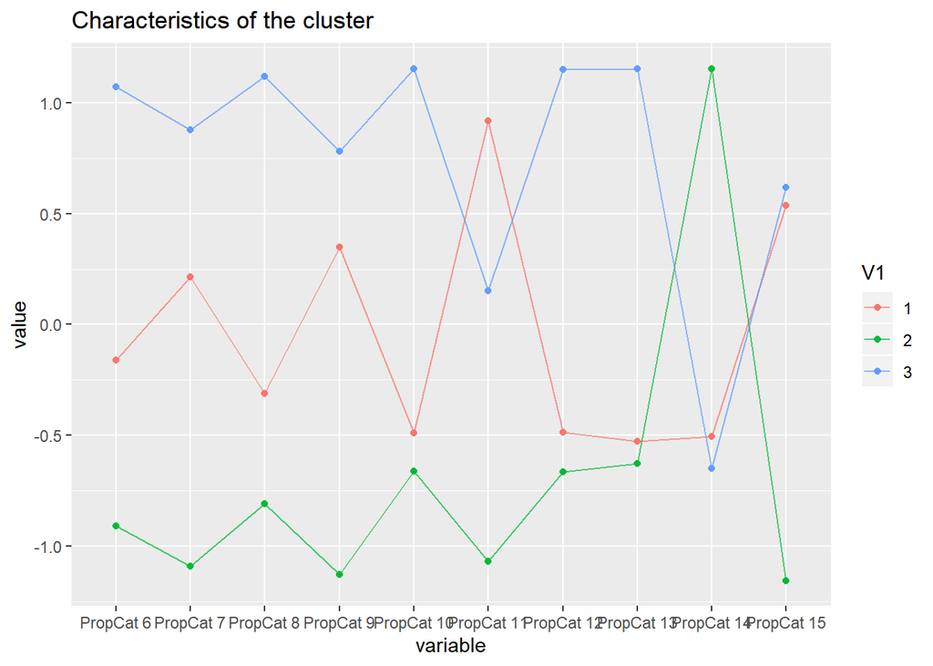

```r
ggparcoord(result40,columns = 27:36, groupColumn = 1,showPoints = TRUE, title = "Characteristics of the cluster",alphaLines = 0.7 )
```

**Comments** Based on plot defining characteristics of the cluster

Cluster2 : -have low socioeconomic class -high transaction per brand -high volume per transaction volume -have loyalty towards a brand -have purchased based on price category 3 -purchase product proposition category 14 -not keen on purchasing product based on promotions

cluster 3: - have a group of people with high socioeconomic class - education level is high - high value of durable possessed hence they have an average price as high - loyal to “other 999” products - look for promotion of at least 6% -volume purchased under price category 1 are high - purchase product proposition category 6,7,8,10,12,13

3. Develop a model that classifies the data into these segments. Since this information would most likely be used in targeting direct-mail promotions, it would be useful to select a market segment that would be defined as a success in the classification model. **comments** here we are using cluster 1 as a base to target our promotional offer since they have 50% of the data point can be used to find characteristics for building model

```r
subset402<- subset40 ##
subset402$clusters<-as.factor( ifelse((subset402$clusters==2) | (subset402$clusters==3), "No","Yes"))

traindata <- subset402[c(1:500),]
testdata <- subset402[c(501:600),]

model402 <- glm(clusters~.,data = traindata,family = binomial(link='logit') )
summary(model402)
```

```
##
## Call:
## glm(formula = clusters ~ ., family = binomial(link = "logit"),
##     data = traindata)
##
## Deviance Residuals:
##     Min       1Q   Median       3Q      Max
## -3.4501  -0.0007   0.0000   0.0031   3.0431
##
## Coefficients:
##                           Estimate Std. Error z value Pr(>|z|)
## (Intercept)             -1.832e+01  1.272e+02  -0.144  0.88549
## SEC                      1.801e+00  5.946e-01   3.029  0.00246 **
## AGE                      7.534e-01  5.682e-01   1.326  0.18483
## EDU                     -2.870e-01  2.985e-01  -0.961  0.33630
## HS                       5.279e-01  4.271e-01   1.236  0.21644
## CHILD                   -8.041e-01  5.536e-01  -1.452  0.14637
## CS                       1.501e+00  1.434e+00   1.046  0.29537
## `Affluence Index`       -1.324e-01  6.989e-02  -1.894  0.05817 .
## `No. of Brands`          2.729e-01  3.910e-01   0.698  0.48516
## `Brand Runs`            -1.850e-01  1.811e-01  -1.021  0.30718
## `Total Volume`           7.381e-04  3.996e-04   1.847  0.06472 .
## `No. of  Trans`          1.035e-02  9.517e-02   0.109  0.91339
## Value                    1.546e-04  2.585e-03   0.060  0.95230
## `Trans / Brand Runs`    -8.042e-01  1.211e+00  -0.664  0.50681
## `Vol/Tran`              -3.700e-03  4.598e-03  -0.805  0.42095
## `Avg. Price`            -8.743e-01  7.070e-01  -1.237  0.21626
## `Others 999`             8.528e-01  3.882e+00   0.220  0.82612
## maxLoyality             -1.123e+01  4.474e+00  -2.511  0.01204 *
## `Pur Vol No Promo - %`   1.715e+02  1.167e+02   1.470  0.14149
## `Pur Vol Promo 6 %`      1.387e+02  1.138e+02   1.218  0.22311
## `Pur Vol Other Promo %`  1.389e+02  1.179e+02   1.178  0.23879
## `Pr Cat 1`              -1.402e+02  9.970e+01  -1.407  0.15952
## `Pr Cat 2`              -1.163e+02  9.742e+01  -1.194  0.23246
## `Pr Cat 3`              -1.188e+02  9.995e+01  -1.189  0.23448
## `Pr Cat 4`              -1.149e+02  9.748e+01  -1.178  0.23861
## `PropCat 5`             -7.123e+00  6.259e+01  -0.114  0.90939
## `PropCat 6`             -1.883e+01  6.202e+01  -0.304  0.76149
## `PropCat 7`             -1.126e+01  6.321e+01  -0.178  0.85864
## `PropCat 8`             -2.631e+01  6.300e+01  -0.418  0.67619
## `PropCat 9`             -2.312e+01  6.386e+01  -0.362  0.71726
## `PropCat 10`            -3.069e+01  6.534e+01  -0.470  0.63858
## `PropCat 11`            -1.492e+01  6.272e+01  -0.238  0.81201
## `PropCat 12`            -5.643e+01  6.924e+01  -0.815  0.41510
## `PropCat 13`            -3.784e+01  6.372e+01  -0.594  0.55261
## `PropCat 14`            -4.659e+01  6.818e+01  -0.683  0.49439
## `PropCat 15`            -1.325e+01  6.474e+01  -0.205  0.83779
## ---
## Signif. codes:  0 '***' 0.001 '**' 0.01 '*' 0.05 '.' 0.1 ' ' 1
##
## (Dispersion parameter for binomial family taken to be 1)
##
##     Null deviance: 689.944  on 499  degrees of freedom
## Residual deviance:  63.182  on 464  degrees of freedom
## AIC: 135.18
##
## Number of Fisher Scoring iterations: 11
```

```r
result402 <- predict(model402,newdata = testdata,type = 'response')
result402<- as.factor(result402>.5)

levels(result402)<- c("No","Yes")

library(gmodels)
CrossTable(testdata$clusters,result402,prop.chisq = FALSE)
```

```
##
##
##    Cell Contents
## |-------------------------|
## |                       N |
## |           N / Row Total |
## |           N / Col Total |
## |         N / Table Total |
## |-------------------------|
##
##
## Total Observations in Table:  100
##
##
##                   | result402
## testdata$clusters |        No |       Yes | Row Total |
## ------------------|-----------|-----------|-----------|
##                No |        49 |         6 |        55 |
##                   |     0.891 |     0.109 |     0.550 |
##                   |     0.942 |     0.125 |           |
##                   |     0.490 |     0.060 |           |
## ------------------|-----------|-----------|-----------|
##               Yes |         3 |        42 |        45 |
##                   |     0.067 |     0.933 |     0.450 |
##                   |     0.058 |     0.875 |           |
##                   |     0.030 |     0.420 |           |
## ------------------|-----------|-----------|-----------|
##      Column Total |        52 |        48 |       100 |
##                   |     0.520 |     0.480 |           |
## ------------------|-----------|-----------|-----------|
##
##
```

```r
confusionMatrix(testdata$clusters,result402)
```

```
## Confusion Matrix and Statistics
##
##           Reference
## Prediction No Yes
##        No  49   6
##        Yes  3  42
##
##                Accuracy : 0.91
##                  95% CI : (0.836, 0.958)
##     No Information Rate : 0.52
##     P-Value [Acc > NIR] : <2e-16
##
##                   Kappa : 0.8193
##
##  Mcnemar's Test P-Value : 0.505
##
##             Sensitivity : 0.9423
##             Specificity : 0.8750
##          Pos Pred Value : 0.8909
##          Neg Pred Value : 0.9333
##              Prevalence : 0.5200
##          Detection Rate : 0.4900
##    Detection Prevalence : 0.5500
##       Balanced Accuracy : 0.9087
##
##        'Positive' Class : No
##
```

```r
subset402$result402 <- result402
```